# Risk Factor Analysis

## Outcome Variable

**Outcome Variable:** swasted

## Predictor Variables

**Intervention Variable:** exclfeed36

**Adjustment Set:**

unadjusted

## Stratifying Variables

The analysis was stratified on these variable(s):

- agecat
- studyid
- country

## Data Summary

| agecat | studyid | country | exclfeed36 | swasted | n_cell | n |
| --- | --- | --- | --- | --- | --- | --- |
| Birth | ki0047075b-MAL-ED | BANGLADESH | 1 | 0 | 31 | 208 |
| Birth | ki0047075b-MAL-ED | BANGLADESH | 1 | 1 | 0 | 208 |
| Birth | ki0047075b-MAL-ED | BANGLADESH | 0 | 0 | 169 | 208 |
| Birth | ki0047075b-MAL-ED | BANGLADESH | 0 | 1 | 8 | 208 |
| Birth | ki0047075b-MAL-ED | BRAZIL | 1 | 0 | 4 | 62 |
| Birth | ki0047075b-MAL-ED | BRAZIL | 1 | 1 | 0 | 62 |
| Birth | ki0047075b-MAL-ED | BRAZIL | 0 | 0 | 58 | 62 |
| Birth | ki0047075b-MAL-ED | BRAZIL | 0 | 1 | 0 | 62 |
| Birth | ki0047075b-MAL-ED | INDIA | 1 | 0 | 1 | 40 |
| Birth | ki0047075b-MAL-ED | INDIA | 1 | 1 | 0 | 40 |
| Birth | ki0047075b-MAL-ED | INDIA | 0 | 0 | 39 | 40 |
| Birth | ki0047075b-MAL-ED | INDIA | 0 | 1 | 0 | 40 |
| Birth | ki0047075b-MAL-ED | NEPAL | 1 | 0 | 0 | 25 |
| Birth | ki0047075b-MAL-ED | NEPAL | 1 | 1 | 0 | 25 |
| Birth | ki0047075b-MAL-ED | NEPAL | 0 | 0 | 24 | 25 |
| Birth | ki0047075b-MAL-ED | NEPAL | 0 | 1 | 1 | 25 |
| Birth | ki0047075b-MAL-ED | PERU | 1 | 0 | 5 | 218 |
| Birth | ki0047075b-MAL-ED | PERU | 1 | 1 | 0 | 218 |
| Birth | ki0047075b-MAL-ED | PERU | 0 | 0 | 213 | 218 |
| Birth | ki0047075b-MAL-ED | PERU | 0 | 1 | 0 | 218 |
| Birth | ki0047075b-MAL-ED | SOUTH AFRICA | 1 | 0 | 1 | 104 |
| Birth | ki0047075b-MAL-ED | SOUTH AFRICA | 1 | 1 | 0 | 104 |
| Birth | ki0047075b-MAL-ED | SOUTH AFRICA | 0 | 0 | 103 | 104 |
| Birth | ki0047075b-MAL-ED | SOUTH AFRICA | 0 | 1 | 0 | 104 |
| Birth | ki0047075b-MAL-ED | TANZANIA, UNITED REPUBLIC OF | 1 | 0 | 0 | 111 |
| Birth | ki0047075b-MAL-ED | TANZANIA, UNITED REPUBLIC OF | 1 | 1 | 0 | 111 |
| Birth | ki0047075b-MAL-ED | TANZANIA, UNITED REPUBLIC OF | 0 | 0 | 111 | 111 |
| Birth | ki0047075b-MAL-ED | TANZANIA, UNITED REPUBLIC OF | 0 | 1 | 0 | 111 |
| Birth | ki1000108-CMC-V-BCS-2002 | INDIA | 1 | 0 | 3 | 3 |
| Birth | ki1000108-CMC-V-BCS-2002 | INDIA | 1 | 1 | 0 | 3 |

[output cut: 162 more lines]

The following strata were considered:

- agecat: 24 months, studyid: ki0047075b-MAL-ED, country: BANGLADESH
- agecat: 24 months, studyid: ki0047075b-MAL-ED, country: BRAZIL
- agecat: 24 months, studyid: ki0047075b-MAL-ED, country: INDIA
- agecat: 24 months, studyid: ki0047075b-MAL-ED, country: NEPAL
- agecat: 24 months, studyid: ki0047075b-MAL-ED, country: PERU
- agecat: 24 months, studyid: ki0047075b-MAL-ED, country: SOUTH AFRICA
- agecat: 24 months, studyid: ki0047075b-MAL-ED, country: TANZANIA, UNITED REPUBLIC OF
- agecat: 24 months, studyid: ki1000108-CMC-V-BCS-2002, country: INDIA
- agecat: 24 months, studyid: ki1000108-IRC, country: INDIA
- agecat: 24 months, studyid: ki1000109-EE, country: PAKISTAN
- agecat: 24 months, studyid: ki1017093b-PROVIDE, country: BANGLADESH
- agecat: 24 months, studyid: ki1101329-Keneba, country: GAMBIA
- agecat: 24 months, studyid: ki1113344-GMS-Nepal, country: NEPAL
- agecat: 24 months, studyid: ki1148112-LCNI-5, country: MALAWI
- agecat: 24 months, studyid: kiGH5241-JiVitA-3, country: BANGLADESH
- agecat: 24 months, studyid: kiGH5241-JiVitA-4, country: BANGLADESH
- agecat: 6 months, studyid: ki0047075b-MAL-ED, country: BANGLADESH
- agecat: 6 months, studyid: ki0047075b-MAL-ED, country: BRAZIL
- agecat: 6 months, studyid: ki0047075b-MAL-ED, country: INDIA
- agecat: 6 months, studyid: ki0047075b-MAL-ED, country: NEPAL
- agecat: 6 months, studyid: ki0047075b-MAL-ED, country: PERU
- agecat: 6 months, studyid: ki0047075b-MAL-ED, country: SOUTH AFRICA
- agecat: 6 months, studyid: ki0047075b-MAL-ED, country: TANZANIA, UNITED REPUBLIC OF
- agecat: 6 months, studyid: ki1000108-CMC-V-BCS-2002, country: INDIA
- agecat: 6 months, studyid: ki1000108-IRC, country: INDIA
- agecat: 6 months, studyid: ki1000109-EE, country: PAKISTAN
- agecat: 6 months, studyid: ki1000304b-SAS-FoodSuppl, country: INDIA
- agecat: 6 months, studyid: ki1017093b-PROVIDE, country: BANGLADESH
- agecat: 6 months, studyid: ki1101329-Keneba, country: GAMBIA
- agecat: 6 months, studyid: ki1113344-GMS-Nepal, country: NEPAL
- agecat: 6 months, studyid: ki1148112-LCNI-5, country: MALAWI
- agecat: 6 months, studyid: kiGH5241-JiVitA-3, country: BANGLADESH
- agecat: 6 months, studyid: kiGH5241-JiVitA-4, country: BANGLADESH
- agecat: Birth, studyid: ki0047075b-MAL-ED, country: BANGLADESH
- agecat: Birth, studyid: ki0047075b-MAL-ED, country: BRAZIL
- agecat: Birth, studyid: ki0047075b-MAL-ED, country: INDIA
- agecat: Birth, studyid: ki0047075b-MAL-ED, country: NEPAL
- agecat: Birth, studyid: ki0047075b-MAL-ED, country: PERU
- agecat: Birth, studyid: ki0047075b-MAL-ED, country: SOUTH AFRICA
- agecat: Birth, studyid: ki0047075b-MAL-ED, country: TANZANIA, UNITED REPUBLIC OF
- agecat: Birth, studyid: ki1000108-CMC-V-BCS-2002, country: INDIA
- agecat: Birth, studyid: ki1000108-IRC, country: INDIA
- agecat: Birth, studyid: ki1000109-EE, country: PAKISTAN
- agecat: Birth, studyid: ki1017093b-PROVIDE, country: BANGLADESH
- agecat: Birth, studyid: ki1101329-Keneba, country: GAMBIA
- agecat: Birth, studyid: ki1113344-GMS-Nepal, country: NEPAL
- agecat: Birth, studyid: kiGH5241-JiVitA-3, country: BANGLADESH
- agecat: Birth, studyid: kiGH5241-JiVitA-4, country: BANGLADESH

### Dropped Strata

Some strata were dropped due to rare outcomes:

- agecat: Birth, studyid: ki0047075b-MAL-ED, country: BANGLADESH
- agecat: Birth, studyid: ki0047075b-MAL-ED, country: BRAZIL
- agecat: Birth, studyid: ki0047075b-MAL-ED, country: INDIA
- agecat: Birth, studyid: ki0047075b-MAL-ED, country: NEPAL
- agecat: Birth, studyid: ki0047075b-MAL-ED, country: PERU
- agecat: Birth, studyid: ki0047075b-MAL-ED, country: SOUTH AFRICA
- agecat: Birth, studyid: ki0047075b-MAL-ED, country: TANZANIA, UNITED REPUBLIC OF
- agecat: Birth, studyid: ki1000108-CMC-V-BCS-2002, country: INDIA
- agecat: Birth, studyid: ki1000108-IRC, country: INDIA
- agecat: Birth, studyid: ki1000109-EE, country: PAKISTAN
- agecat: Birth, studyid: ki1017093b-PROVIDE, country: BANGLADESH
- agecat: Birth, studyid: ki1113344-GMS-Nepal, country: NEPAL
- agecat: 6 months, studyid: ki0047075b-MAL-ED, country: BANGLADESH
- agecat: 6 months, studyid: ki0047075b-MAL-ED, country: BRAZIL
- agecat: 6 months, studyid: ki0047075b-MAL-ED, country: INDIA
- agecat: 6 months, studyid: ki0047075b-MAL-ED, country: NEPAL
- agecat: 6 months, studyid: ki0047075b-MAL-ED, country: PERU
- agecat: 6 months, studyid: ki0047075b-MAL-ED, country: SOUTH AFRICA
- agecat: 6 months, studyid: ki0047075b-MAL-ED, country: TANZANIA, UNITED REPUBLIC OF
- agecat: 6 months, studyid: ki1000108-CMC-V-BCS-2002, country: INDIA
- agecat: 6 months, studyid: ki1000108-IRC, country: INDIA
- agecat: 6 months, studyid: ki1000109-EE, country: PAKISTAN
- agecat: 6 months, studyid: ki1000304b-SAS-FoodSuppl, country: INDIA
- agecat: 6 months, studyid: ki1017093b-PROVIDE, country: BANGLADESH
- agecat: 6 months, studyid: ki1113344-GMS-Nepal, country: NEPAL
- agecat: 6 months, studyid: ki1148112-LCNI-5, country: MALAWI
- agecat: 24 months, studyid: ki0047075b-MAL-ED, country: BANGLADESH
- agecat: 24 months, studyid: ki0047075b-MAL-ED, country: BRAZIL
- agecat: 24 months, studyid: ki0047075b-MAL-ED, country: INDIA
- agecat: 24 months, studyid: ki0047075b-MAL-ED, country: NEPAL
- agecat: 24 months, studyid: ki0047075b-MAL-ED, country: PERU
- agecat: 24 months, studyid: ki0047075b-MAL-ED, country: SOUTH AFRICA
- agecat: 24 months, studyid: ki0047075b-MAL-ED, country: TANZANIA, UNITED REPUBLIC OF
- agecat: 24 months, studyid: ki1000108-CMC-V-BCS-2002, country: INDIA
- agecat: 24 months, studyid: ki1000108-IRC, country: INDIA
- agecat: 24 months, studyid: ki1000109-EE, country: PAKISTAN
- agecat: 24 months, studyid: ki1017093b-PROVIDE, country: BANGLADESH
- agecat: 24 months, studyid: ki1148112-LCNI-5, country: MALAWI

## Methods Detail

We’re interested in the causal parameters $E[Y_a]$ for all values of $a \in \mathcal{A}$. These parameters represent the mean outcome if, possibly contrary to fact, we intervened to set all units to have $A=a$. Under the randomization and positivity assumptions, these are identified by the statistical parameters $\psi_a=E_W[E_{Y|A,W}(Y|A=a,W)]$. In addition, we’re interested in the mean of $Y$, $E[Y]$ under no intervention (the observed mean). We will estimate these parameters by using SuperLearner to fit the relevant likelihood factors – $E_{Y|A,W}(Y|A=a,W)$ and $p(A=a|W)$, and then updating our likelihood fit using a joint TMLE.

For unadjusted analyses ($W=\{\}$), initial likelihoods were estimated using Lrnr_glm to estimate the simple $E(Y|A)$ and Lrnr_mean to estimate $p(A)$. For adjusted analyses, a small library containing Lrnr_glmnet, Lrnr_xgboost, and Lrnr_mean was used.

Having estimated these parameters, we will then use the delta method to estimate relative risks and attributable risks relative to a prespecified baseline level of $A$.

# Results Detail

## Results Plots

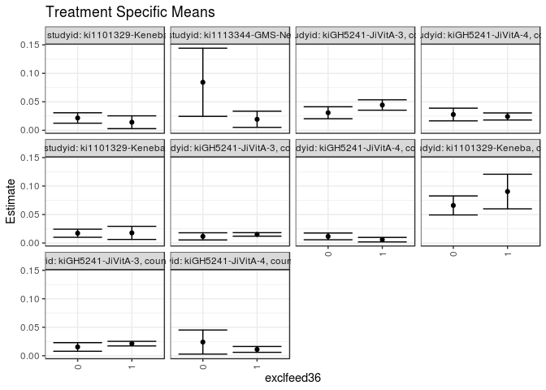

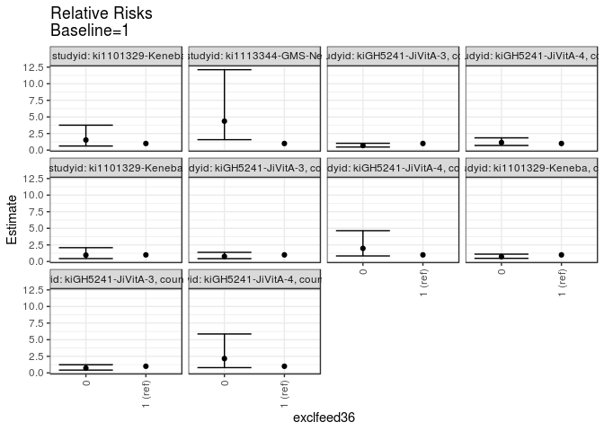

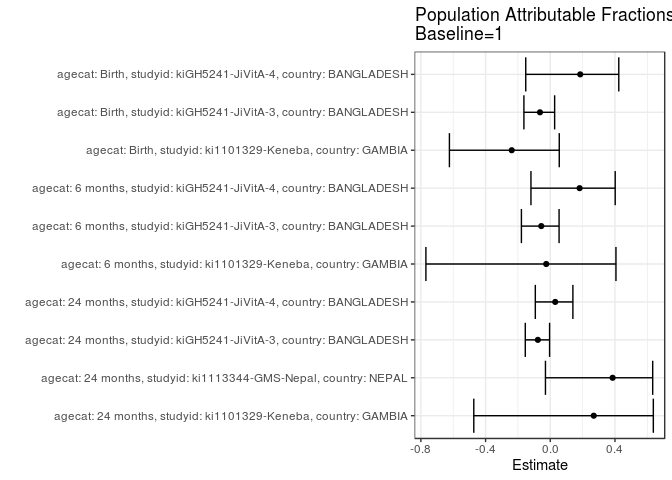

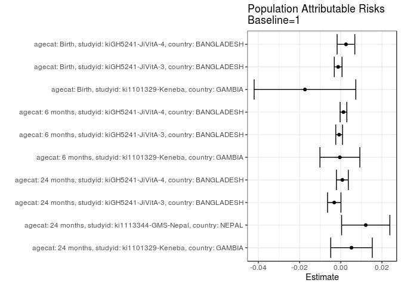

## Results Table

### Parameter: TSM

| agecat | studyid | country | intervention_level | baseline_level | estimate | ci_lower | ci_upper |
| --- | --- | --- | --- | --- | --- | --- | --- |
| Birth | ki1101329-Keneba | GAMBIA | 1 | NA | 0.0903790 | 0.0600228 | 0.1207352 |
| Birth | ki1101329-Keneba | GAMBIA | 0 | NA | 0.0659600 | 0.0492568 | 0.0826631 |
| Birth | kiGH5241-JiVitA-3 | BANGLADESH | 1 | NA | 0.0212292 | 0.0172096 | 0.0252489 |
| Birth | kiGH5241-JiVitA-3 | BANGLADESH | 0 | NA | 0.0154010 | 0.0078622 | 0.0229397 |
| Birth | kiGH5241-JiVitA-4 | BANGLADESH | 1 | NA | 0.0111046 | 0.0059718 | 0.0162374 |
| Birth | kiGH5241-JiVitA-4 | BANGLADESH | 0 | NA | 0.0239808 | 0.0027986 | 0.0451630 |
| 6 months | ki1101329-Keneba | GAMBIA | 1 | NA | 0.0177515 | 0.0062542 | 0.0292487 |
| 6 months | ki1101329-Keneba | GAMBIA | 0 | NA | 0.0171473 | 0.0100418 | 0.0242529 |
| 6 months | kiGH5241-JiVitA-3 | BANGLADESH | 1 | NA | 0.0150892 | 0.0120080 | 0.0181703 |
| 6 months | kiGH5241-JiVitA-3 | BANGLADESH | 0 | NA | 0.0116515 | 0.0053528 | 0.0179501 |
| 6 months | kiGH5241-JiVitA-4 | BANGLADESH | 1 | NA | 0.0058642 | 0.0019011 | 0.0098273 |
| 6 months | kiGH5241-JiVitA-4 | BANGLADESH | 0 | NA | 0.0116034 | 0.0056831 | 0.0175236 |
| 24 months | ki1101329-Keneba | GAMBIA | 1 | NA | 0.0141509 | 0.0029044 | 0.0253975 |
| 24 months | ki1101329-Keneba | GAMBIA | 0 | NA | 0.0216272 | 0.0124745 | 0.0307798 |
| 24 months | ki1113344-GMS-Nepal | NEPAL | 1 | NA | 0.0193370 | 0.0051354 | 0.0335386 |
| 24 months | ki1113344-GMS-Nepal | NEPAL | 0 | NA | 0.0843373 | 0.0244858 | 0.1441889 |
| 24 months | kiGH5241-JiVitA-3 | BANGLADESH | 1 | NA | 0.0443975 | 0.0352628 | 0.0535321 |
| 24 months | kiGH5241-JiVitA-3 | BANGLADESH | 0 | NA | 0.0308151 | 0.0203077 | 0.0413225 |
| 24 months | kiGH5241-JiVitA-4 | BANGLADESH | 1 | NA | 0.0242656 | 0.0180464 | 0.0304849 |
| 24 months | kiGH5241-JiVitA-4 | BANGLADESH | 0 | NA | 0.0276855 | 0.0165248 | 0.0388461 |

### Parameter: E(Y)

| agecat | studyid | country | intervention_level | baseline_level | estimate | ci_lower | ci_upper |
| --- | --- | --- | --- | --- | --- | --- | --- |
| Birth | ki1101329-Keneba | GAMBIA | NA | NA | 0.0729866 | 0.0582140 | 0.0877592 |
| Birth | kiGH5241-JiVitA-3 | BANGLADESH | NA | NA | 0.0199559 | 0.0164404 | 0.0234714 |
| Birth | kiGH5241-JiVitA-4 | BANGLADESH | NA | NA | 0.0136278 | 0.0077812 | 0.0194744 |
| 6 months | ki1101329-Keneba | GAMBIA | NA | NA | 0.0173184 | 0.0112733 | 0.0233635 |
| 6 months | kiGH5241-JiVitA-3 | BANGLADESH | NA | NA | 0.0142941 | 0.0115468 | 0.0170414 |
| 6 months | kiGH5241-JiVitA-4 | BANGLADESH | NA | NA | 0.0071633 | 0.0038384 | 0.0104883 |
| 24 months | ki1101329-Keneba | GAMBIA | NA | NA | 0.0193548 | 0.0121227 | 0.0265870 |
| 24 months | ki1113344-GMS-Nepal | NEPAL | NA | NA | 0.0314607 | 0.0152239 | 0.0476974 |
| 24 months | kiGH5241-JiVitA-3 | BANGLADESH | NA | NA | 0.0412323 | 0.0338115 | 0.0486531 |
| 24 months | kiGH5241-JiVitA-4 | BANGLADESH | NA | NA | 0.0250310 | 0.0196459 | 0.0304161 |

### Parameter: RR

| agecat | studyid | country | intervention_level | baseline_level | estimate | ci_lower | ci_upper |
| --- | --- | --- | --- | --- | --- | --- | --- |
| Birth | ki1101329-Keneba | GAMBIA | 1 | 1 | 1.0000000 | 1.0000000 | 1.000000 |
| Birth | ki1101329-Keneba | GAMBIA | 0 | 1 | 0.7298150 | 0.4792149 | 1.111464 |
| Birth | kiGH5241-JiVitA-3 | BANGLADESH | 1 | 1 | 1.0000000 | 1.0000000 | 1.000000 |
| Birth | kiGH5241-JiVitA-3 | BANGLADESH | 0 | 1 | 0.7254606 | 0.4273774 | 1.231448 |
| Birth | kiGH5241-JiVitA-4 | BANGLADESH | 1 | 1 | 1.0000000 | 1.0000000 | 1.000000 |
| Birth | kiGH5241-JiVitA-4 | BANGLADESH | 0 | 1 | 2.1595355 | 0.7953971 | 5.863227 |
| 6 months | ki1101329-Keneba | GAMBIA | 1 | 1 | 1.0000000 | 1.0000000 | 1.000000 |
| 6 months | ki1101329-Keneba | GAMBIA | 0 | 1 | 0.9659652 | 0.4477489 | 2.083955 |
| 6 months | kiGH5241-JiVitA-3 | BANGLADESH | 1 | 1 | 1.0000000 | 1.0000000 | 1.000000 |
| 6 months | kiGH5241-JiVitA-3 | BANGLADESH | 0 | 1 | 0.7721746 | 0.4308455 | 1.383915 |
| 6 months | kiGH5241-JiVitA-4 | BANGLADESH | 1 | 1 | 1.0000000 | 1.0000000 | 1.000000 |
| 6 months | kiGH5241-JiVitA-4 | BANGLADESH | 0 | 1 | 1.9786809 | 0.8427890 | 4.645502 |
| 24 months | ki1101329-Keneba | GAMBIA | 1 | 1 | 1.0000000 | 1.0000000 | 1.000000 |
| 24 months | ki1101329-Keneba | GAMBIA | 0 | 1 | 1.5283213 | 0.6211156 | 3.760598 |
| 24 months | ki1113344-GMS-Nepal | NEPAL | 1 | 1 | 1.0000000 | 1.0000000 | 1.000000 |
| 24 months | ki1113344-GMS-Nepal | NEPAL | 0 | 1 | 4.3614457 | 1.5707064 | 12.110608 |
| 24 months | kiGH5241-JiVitA-3 | BANGLADESH | 1 | 1 | 1.0000000 | 1.0000000 | 1.000000 |
| 24 months | kiGH5241-JiVitA-3 | BANGLADESH | 0 | 1 | 0.6940737 | 0.4659772 | 1.033824 |
| 24 months | kiGH5241-JiVitA-4 | BANGLADESH | 1 | 1 | 1.0000000 | 1.0000000 | 1.000000 |
| 24 months | kiGH5241-JiVitA-4 | BANGLADESH | 0 | 1 | 1.1409337 | 0.7042883 | 1.848291 |

### Parameter: PAR

| agecat | studyid | country | intervention_level | baseline_level | estimate | ci_lower | ci_upper |
| --- | --- | --- | --- | --- | --- | --- | --- |
| Birth | ki1101329-Keneba | GAMBIA | 1 | NA | -0.0173924 | -0.0420785 | 0.0072936 |
| Birth | kiGH5241-JiVitA-3 | BANGLADESH | 1 | NA | -0.0012733 | -0.0031572 | 0.0006106 |
| Birth | kiGH5241-JiVitA-4 | BANGLADESH | 1 | NA | 0.0025232 | -0.0017731 | 0.0068195 |
| 6 months | ki1101329-Keneba | GAMBIA | 1 | NA | -0.0004330 | -0.0101206 | 0.0092545 |
| 6 months | kiGH5241-JiVitA-3 | BANGLADESH | 1 | NA | -0.0007951 | -0.0024362 | 0.0008460 |
| 6 months | kiGH5241-JiVitA-4 | BANGLADESH | 1 | NA | 0.0012991 | -0.0003258 | 0.0029240 |
| 24 months | ki1101329-Keneba | GAMBIA | 1 | NA | 0.0052039 | -0.0048907 | 0.0152985 |
| 24 months | ki1113344-GMS-Nepal | NEPAL | 1 | NA | 0.0121237 | 0.0004112 | 0.0238361 |
| 24 months | kiGH5241-JiVitA-3 | BANGLADESH | 1 | NA | -0.0031651 | -0.0064239 | 0.0000936 |
| 24 months | kiGH5241-JiVitA-4 | BANGLADESH | 1 | NA | 0.0007653 | -0.0021230 | 0.0036537 |

### Parameter: PAF

| agecat | studyid | country | intervention_level | baseline_level | estimate | ci_lower | ci_upper |
| --- | --- | --- | --- | --- | --- | --- | --- |
| Birth | ki1101329-Keneba | GAMBIA | 1 | NA | -0.2382963 | -0.6235760 | 0.0555553 |
| Birth | kiGH5241-JiVitA-3 | BANGLADESH | 1 | NA | -0.0638059 | -0.1630226 | 0.0269468 |
| Birth | kiGH5241-JiVitA-4 | BANGLADESH | 1 | NA | 0.1851508 | -0.1516967 | 0.4234774 |
| 6 months | ki1101329-Keneba | GAMBIA | 1 | NA | -0.0250048 | -0.7689132 | 0.4060563 |
| 6 months | kiGH5241-JiVitA-3 | BANGLADESH | 1 | NA | -0.0556230 | -0.1784421 | 0.0543957 |
| 6 months | kiGH5241-JiVitA-4 | BANGLADESH | 1 | NA | 0.1813580 | -0.1194835 | 0.4013537 |
| 24 months | ki1101329-Keneba | GAMBIA | 1 | NA | 0.2688679 | -0.4728780 | 0.6370683 |
| 24 months | ki1113344-GMS-Nepal | NEPAL | 1 | NA | 0.3853591 | -0.0298156 | 0.6331543 |
| 24 months | kiGH5241-JiVitA-3 | BANGLADESH | 1 | NA | -0.0767632 | -0.1545129 | -0.0042495 |
| 24 months | kiGH5241-JiVitA-4 | BANGLADESH | 1 | NA | 0.0305755 | -0.0924930 | 0.1397804 |